# 資料分組

wuyijin

2019年2月19日

- 次數分配表
  - 資料集合的一種表格彙總方式，用以顯示不相重疊的各個資料組別中各自含有的觀察值次數。
  - 次數分配的優點是提供了一個比原始資料更容易瞭解的資料彙整方式。
  - 組：區間
  - 組中間值：每組的代表值(每組中位數)
  - 組距：每組的範圍
  - 全距：R = 最大值 - 最小值(衡量一組數據分散程度最簡單的指標。當有離群值或樣本很大，不是很好的指標。)
  - 相對次數：次數除以總次數(看出全體總佔比)
- 以各家拉麵店價錢為例，製作次數分配表
  - 步驟1：匯入資料

  ```r
  theUrl <- "https://raw.githubusercontent.com/yijinwu1/R/master/excel/RamenShop.csv"

  df.csv <- read.csv(theUrl,skip=1,header = FALSE,
                     col.names = c('shopNo','Price'))
  df.csv
  ```

  ```
  ##    shopNo Price
  ## 1       1   700
  ## 2       2   800
  ## 3       3   600
  ## 4       4   650
  ## 5       5   980
  ## 6       6   750
  ## 7       7   500
  ## 8       8   890
  ## 9       9   880
  ## 10     10   700
  ## 11     11   890
  ## 12     12   720
  ## 13     13   680
  ## 14     14   650
  ```

  [output cut: 36 more lines]

  - 散布圖

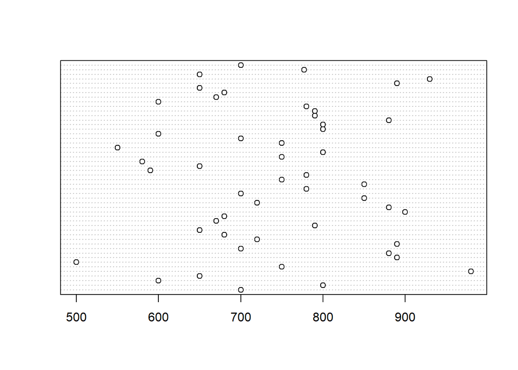

    ```r
    dotchart(df.csv$Price)
    ```

    - 長條圖

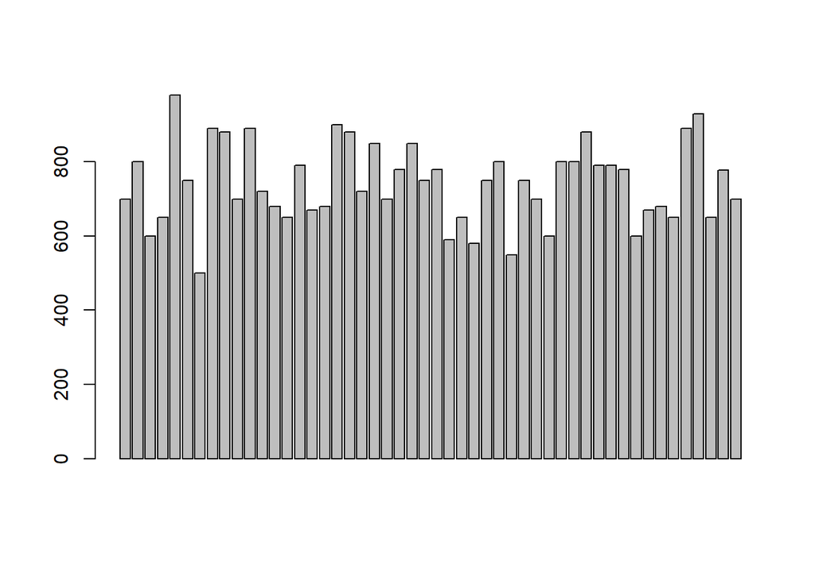

    ```r
    barplot(df.csv$Price)
    ```

  - 步驟2：算出最大值、最小值、全距

  ```r
  max.price <- max(df.csv$Price)
  max.price #最大值
  ```

  ```
  ## [1] 980
  ```

  ```r
  min.price <- min(df.csv$Price)
  min.price #最小值
  ```

  ```
  ## [1] 500
  ```

  ```r
  range.price <- max.price - min.price
  range.price #全距
  ```

  ```
  ## [1] 480
  ```

  - 步驟3：設定分成幾組、每組上下限
    - 1自己給
    - 2史特吉斯（Sturges）公式，k＝1+3.32log n
    - 3參考表

      | 數據數目 | 組數 |
      | --- | --- |
      | 50 ~ 100 | 6 ~ 10 |
      | 100 ~ 250 | 7 ~ 12 |
      | 250以上 | 10 ~ 20 |

  ```r
  n.group <- 6 # 資料量50筆，分6組
  int.group <- ceiling(range.price/n.group) #組距:如果不整除的話要將組距無條件進位，或作適當的進位處理。
  int.group
  ```

  ```
  ## [1] 80
  ```

  ```r
  upper.limit <- min.price+n.group*int.group
  group.limit <- seq(min.price, upper.limit, int.group)
  group.limit #每組上下限
  ```

  ```
  ## [1] 500 580 660 740 820 900 980
  ```

  - 步驟4：次數分配表  
    cut(x, breaks, labels = NULL,include.lowest = FALSE, right = TRUE, dig.lab = 3,ordered_result = FALSE, …)
    - labels:By default, labels are constructed using “(a,b]” interval notation. If labels = FALSE, simple integer codes are returned instead of a factor
    - cut指令會包含上限但不包含下限的數值，因此會發生等於0沒辦法被歸類的問題，加上include.lowest=T，讓等於0的可被放到最低的那組裡面去。

  ```r
  group.price <- cut(df.csv$Price, breaks=group.limit, include.lowest=TRUE)
  group.price <- as.data.frame(group.price)
  df.csv <- as.data.frame(cbind(df.csv,group.price)) #add clo group
  df.csv
  ```

  ```
  ##    shopNo Price group.price
  ## 1       1   700   (660,740]
  ## 2       2   800   (740,820]
  ## 3       3   600   (580,660]
  ## 4       4   650   (580,660]
  ## 5       5   980   (900,980]
  ## 6       6   750   (740,820]
  ## 7       7   500   [500,580]
  ## 8       8   890   (820,900]
  ## 9       9   880   (820,900]
  ## 10     10   700   (660,740]
  ## 11     11   890   (820,900]
  ## 12     12   720   (660,740]
  ## 13     13   680   (660,740]
  ## 14     14   650   (580,660]
  ```

  [output cut: 36 more lines]

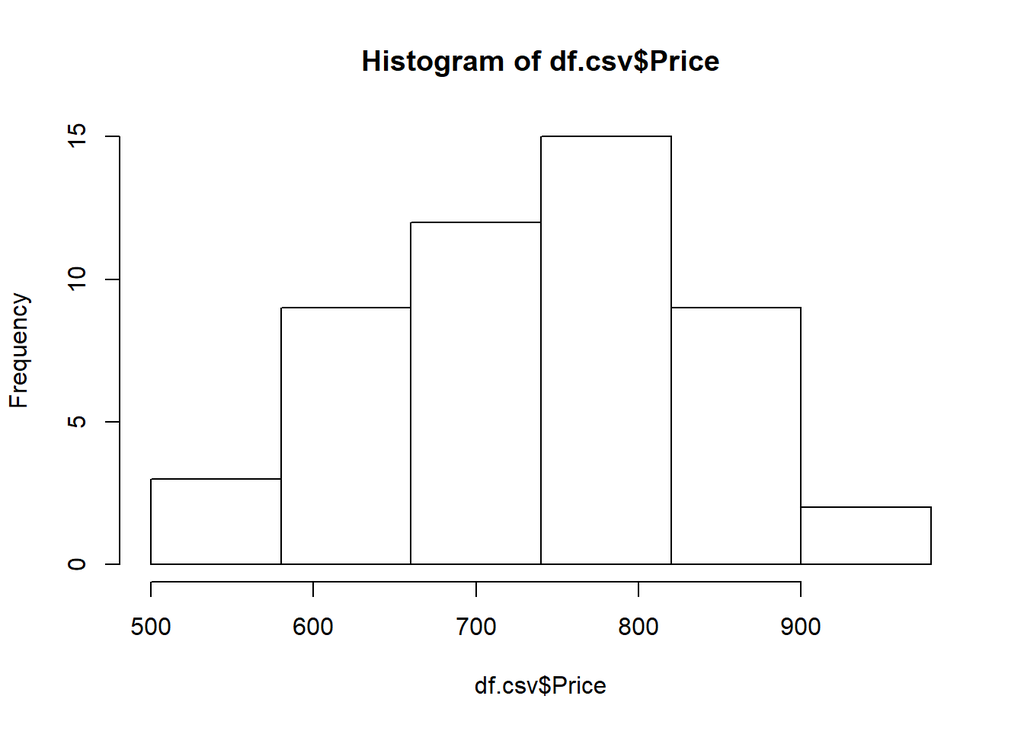

    ```r
    hist(df.csv$Price,breaks=group.limit, include.lowest=T) # Frequency
    ```

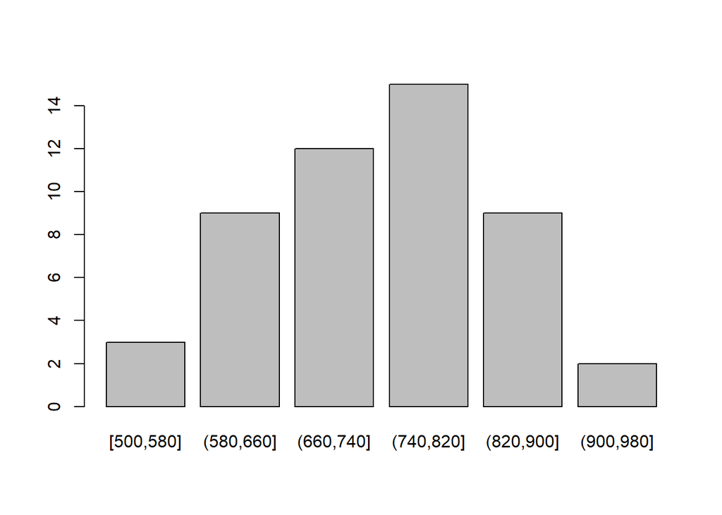

    ```r
    plot(group.price, type='l')
    ```

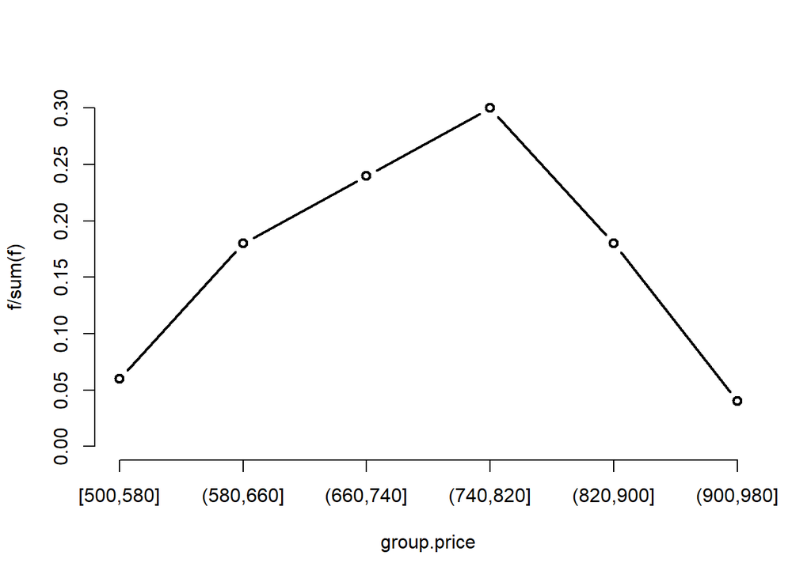

    ```r
    f <- table(group.price)
    plot(f/sum(f), type='b')
    ```